# Datos AEMET/ BICIMAD 2020

by [Juan Manuel Ortiz](https://www.linkedin.com/in/juan-manuel-ortiz-10956a80/)

27/7/2020

En este ejemplo me propongo obtener los datos meteorologicos de AEMET en Madrid durante los primeros 6 meses y contrastarlos con los de Bicimad.

Haremos uso del Open Data, obteniendo los datos de diversas maneras, para posteriormente hacer un breve contraste y analisis.

## Preparación librerias

Cargamos las librerias necesarias para realizar este proyecto

```r
library(jsonlite)
library(RCurl)
library(plyr)
library(dplyr)
library(ggplot2)
library(quantreg)
library(utils)
library(hrbrthemes)
```

## Obtener datos

En este punto procedemos a la descarga de los datos y descomprimimos. Posteriormente la información de los archivos JSON es extraida y convertida a un único dataframe. Como el proceso es largo y tedioso dependiendo de nuestros equipos, sugiero saltarse este punto y cargar directamente el archivo ya tratado

```r
#Descargaros y descomprimimos desde la siguiente dirección los archivos que contienen los datos de uso de Bicimad desde enero hasta Junio de 2020

#https://opendata.emtmadrid.es/Datos-estaticos/Datos-generales-(1)


url <- 'https://opendata.emtmadrid.es/getattachment/fdf6b8d5-7fef-428c-b886-a21bf65f41c4/BiciMAD_movements_2020_1_5.aspx'
destfile <- "C:/opendata/movements_2020_1_5.zip"
download.file(url, destfile,mode="wb")
unzip("movements_2020_1_5.zip")

url <- 'https://opendata.emtmadrid.es/getattachment/c569c188-ca83-46fc-9fc3-95e6701140b2/202006_movements.aspx'
destfile <- "C:/opendata/202006_movements.zip"
download.file(url, destfile,mode="wb")
unzip("202006_movements.zip")

# Leemos los archivos JSON y extraemos su información en Data Frame

archivo <- "C:/opendata/202001_movements.json"
out <- lapply(readLines(archivo), fromJSON)
df <- ldply (out, data.frame)

archivo <- "C:/opendata/202002_movements.json"
out <- lapply(readLines(archivo), fromJSON)
feb <- ldply (out, data.frame)

archivo <- "C:/opendata/202003_movements.json"
out <- lapply(readLines(archivo), fromJSON)
mar <- ldply (out, data.frame)

archivo <- "C:/opendata/202004_movements.json"
out <- lapply(readLines(archivo), fromJSON)
abr <- ldply

archivo <- "C:/opendata/202005_movements.json"
out <- lapply(readLines(archivo), fromJSON)
may <- ldply (out, data.frame)

archivo <- "C:/opendata/202006_movements.json"
out <- lapply(readLines(archivo), fromJSON)
jun <- ldply (out, data.frame)

#Unimos los Data Frame generados en uno solo

bicimad <- rbind(df,feb,mar,abr,may,jun)
```

Ahora procedemos a descargar desde Aemet los datos de la estación de Madrid desde el 01/01/2020 hasta el 15/06/2020 para hacerlos coincidir con los datos de Bicimad descargados anteriormente.

Este punto puede que no funcione en algún momento ya que el link de descarga tiene fecha de caducidad. Por ese motivo posteriormente procedo a guardar la información en un archivo .RData para que podamos trabajar con ello.

```r
# Para obtener la información debemos acceder al siguiente link. Anteriormente debemos solicitar un token para poder tener acceso.

# https://opendata.aemet.es/centrodedescargas/productosAEMET?

# Nos generara una petición de este estilo

# https://opendata.aemet.es/opendata/api/valores/climatologicos/diarios/datos/fechaini/2020-01-01T00:00:00UTC/fechafin/2020-06-15T23:59:59UTC/estacion/3195/?api_key=eyJhbGciOiJIUzI1NiJ9.eyJzdWIiOiJqdWFubWlja0Bob3RtYWlsLmNvbSIsImp0aSI6ImNiZjA5YTc2….nq1Fh0C0FIVw9HS4EjukhELZCKGz2GdFmbp8G4svvTo

# Y esta será la URL obtenida en aemet desde donde descargaremos los datos. Esta url posiblemente caduque y no pueda ser ejecutada.

url  <- "https://opendata.aemet.es/opendata/sh/d0b912eb"

# Leemos los datos en JSON
datos <- readLines(url, warn = FALSE)

# Lo convertimos a dataframe
estacion <- fromJSON(datos)
```

Se guarda el entorno,para ahorrarnos este proceso cada vez que queramos trabajar con los dataframe generados

```r
#Guardamos los Dataframe generados en un único archivo para facilitar su trabajo y no tener que pasar por todo el proceso anterior cada vez que queramos trabajar con ello.

save(bicimad, estacion, file = "bicimad2020.RData")
```

Cargamos el archivo que contiene los dataframe generados anteriormente

```r
# El archivo con los Data Frame ya generados se pueden descargar desde la siguiente url:
# https://drive.google.com/file/d/1SwmUgxrgMgok2q8Nl5MvfDQZmYwX1Sbe/view?usp=sharing

load('bicimad2020.RData')
```

## Limpieza de datos

Nos ocupamos ahora de la tabla que vamos a generar a raiz de los datos de Bicimad

```r
# Mostramos sus primeras 10 lineas
head(bicimad)
```

```
##                      X.oid
## 1 5eeb03e42ea8f656fc95f2a4
## 2 5eeb03e42ea8f656fc95f2a7
## 3 5eeb03e42ea8f656fc95f2aa
## 4 5eeb03e42ea8f656fc95f2ad
## 5 5eeb03e42ea8f656fc95f2b1
## 6 5eeb03e42ea8f656fc95f2bb
##                                                      user_day_code idplug_base
## 1 c87385356e6eb4b9854a2e64f719017d1023e3de201abbf34b4e62e485efa7d4           1
## 2 35190181c1ada5deae3e8d51d05aee4090267969a20975591c254c43d0595d82           1
## 3 f77e4af707dfc3753aea3a3964923f256ef9c0be1413998c1f084b6c8ae82a2f          19
## 4 b7ff183e57cd412f698349540a4c729d0e4e396f4fc5866c532b744453777cd1           1
## 5 f272ac2e59e493866254c364c86253edd7fae80ff4706f45878ef6d9999005ec          12
## 6 0c10ad1b088da0fd7003cad88aedc1f2859ca93fa3646e26e16c6b84e6095646          12
##   user_type idunplug_base travel_time idunplug_station ageRange idplug_station
## 1         1            21         210               87        2             78
## 2         1            21         401               58        4            168
## 3         1            23         473              129        4             82
## 4         1            19         285              208        4              8
## 5         1             8         436                9        4            166
## 6         1            17         459               84        4             44
##        unplug_hourTime zip_code
## 1 2020-01-01T00:00:00Z    28007
## 2 2020-01-01T00:00:00Z    28004
## 3 2020-01-01T00:00:00Z    28045
## 4 2020-01-01T00:00:00Z    28004
## 5 2020-01-01T00:00:00Z    28020
## 6 2020-01-01T00:00:00Z    28521
```

```r
# Mostramos su estructura
str(bicimad)
```

```
## 'data.frame':    1243690 obs. of  11 variables:
##  $ X.oid           : chr  "5eeb03e42ea8f656fc95f2a4" "5eeb03e42ea8f656fc95f2a7" "5eeb03e42ea8f656fc95f2aa" "5eeb03e42ea8f656fc95f2ad" ...
##  $ user_day_code   : chr  "c87385356e6eb4b9854a2e64f719017d1023e3de201abbf34b4e62e485efa7d4" "35190181c1ada5deae3e8d51d05aee4090267969a20975591c254c43d0595d82" "f77e4af707dfc3753aea3a3964923f256ef9c0be1413998c1f084b6c8ae82a2f" "b7ff183e57cd412f698349540a4c729d0e4e396f4fc5866c532b744453777cd1" ...
##  $ idplug_base     : int  1 1 19 1 12 12 21 6 9 15 ...
##  $ user_type       : int  1 1 1 1 1 1 1 1 1 1 ...
##  $ idunplug_base   : int  21 21 23 19 8 17 12 2 22 23 ...
##  $ travel_time     : int  210 401 473 285 436 459 295 365 435 890 ...
##  $ idunplug_station: int  87 58 129 208 9 84 41 160 164 213 ...
##  $ ageRange        : int  2 4 4 4 4 4 5 0 4 0 ...
##  $ idplug_station  : int  78 168 82 8 166 44 26 14 202 125 ...
##  $ unplug_hourTime : chr  "2020-01-01T00:00:00Z" "2020-01-01T00:00:00Z" "2020-01-01T00:00:00Z" "2020-01-01T00:00:00Z" ...
##  $ zip_code        : chr  "28007" "28004" "28045" "28004" ...
```

Limpiamos el dataset con la información de Bicimad para quedarnos en este caso con la información que nos interesa, en este caso nos interesa el número de veces que se utilizan las bicis cada día del año.

```r
# Eliminamos columnas que pueden ser utiles para otros analisis

bicimad$X.oid <- NULL
bicimad$user_day_code <- NULL
bicimad$idplug_base <- NULL
bicimad$idunplug_base <- NULL
bicimad$zip_code <- NULL

# Convertimos en formato fecha

bicimad$fecha <- as.Date(bicimad$unplug_hourTime)
bicimad$unplug_hourTime <- NULL

# Tabla de veces que se cogen las bicis cada día en total
unplug <- bicimad
unplug$user_type <- NULL
unplug$travel_time <- NULL
unplug$ageRange <- NULL
unplug$idplug_station <- NULL

unplug1 <- unplug %>% group_by(fecha)  %>% tally()
names (unplug1)[2] = "vecescogen"

# Tabla de veces que se dejan las bicis en total

plug <- bicimad
plug$user_type <- NULL
plug$travel_time <- NULL
plug$ageRange <- NULL
plug$idunplug_station <- NULL

plug1 <- plug %>% group_by(fecha)  %>% tally()
names (plug1)[2] = "vecesdejan"

# Como las bicis son repuestas al final de cada día, es evidente que el número de veces que se cogen es igual al de veces que se dejan como se puede ver en las tablas creadas

head(unplug1)
```

```
## # A tibble: 6 x 2
##   fecha      vecescogen
##   <date>          <int>
## 1 2020-01-01       3363
## 2 2020-01-02       6324
## 3 2020-01-03       6631
## 4 2020-01-04       5674
## 5 2020-01-05       5483
## 6 2020-01-06       4442
```

```r
head(plug1)
```

```
## # A tibble: 6 x 2
##   fecha      vecesdejan
##   <date>          <int>
## 1 2020-01-01       3363
## 2 2020-01-02       6324
## 3 2020-01-03       6631
## 4 2020-01-04       5674
## 5 2020-01-05       5483
## 6 2020-01-06       4442
```

Ahora nos ocupamos de la información relevante para nuestro analisis de la información meteorologica recabada en Madrid.

```r
# Mostramos sus primeras 10 lineas
head(estacion)
```

```
##        fecha indicativo         nombre provincia altitud tmed prec tmin
## 1 2020-01-01       3195 MADRID, RETIRO    MADRID     667  6,6  0,0  1,9
## 2 2020-01-02       3195 MADRID, RETIRO    MADRID     667  6,0  0,0  1,6
## 3 2020-01-03       3195 MADRID, RETIRO    MADRID     667  3,8  0,0  1,5
## 4 2020-01-04       3195 MADRID, RETIRO    MADRID     667  7,0  0,0  2,8
## 5 2020-01-05       3195 MADRID, RETIRO    MADRID     667  6,2  0,0  1,5
## 6 2020-01-06       3195 MADRID, RETIRO    MADRID     667  6,7  0,0  1,4
##   horatmin tmax horatmax dir velmedia racha horaracha presMax horaPresMax
## 1    07:50 11,2    15:30  05      0,3   3,3     00:50   954,2          11
## 2    07:00 10,5    15:00  99      0,6   3,3    Varias   953,7          10
## 3    06:00  6,0    14:40  99      0,6   5,0    Varias   954,8      Varias
## 4    00:20 11,2    14:45  04      2,5   9,4     12:00   955,9          10
## 5    08:30 10,9    13:50  05      0,8   5,3     00:00   953,3          00
## 6    07:10 12,0    15:00  05      0,6   3,6     01:10   951,7          22
##   presMin horaPresMin
## 1   952,0      Varias
## 2   951,0          15
## 3   952,2      Varias
## 4   952,5          16
## 5   949,2          16
## 6   949,3          01
```

```r
# Mostramos su estructura
str(estacion)
```

```
## 'data.frame':    167 obs. of  19 variables:
##  $ fecha      : chr  "2020-01-01" "2020-01-02" "2020-01-03" "2020-01-04" ...
##  $ indicativo : chr  "3195" "3195" "3195" "3195" ...
##  $ nombre     : chr  "MADRID, RETIRO" "MADRID, RETIRO" "MADRID, RETIRO" "MADRID, RETIRO" ...
##  $ provincia  : chr  "MADRID" "MADRID" "MADRID" "MADRID" ...
##  $ altitud    : chr  "667" "667" "667" "667" ...
##  $ tmed       : chr  "6,6" "6,0" "3,8" "7,0" ...
##  $ prec       : chr  "0,0" "0,0" "0,0" "0,0" ...
##  $ tmin       : chr  "1,9" "1,6" "1,5" "2,8" ...
##  $ horatmin   : chr  "07:50" "07:00" "06:00" "00:20" ...
##  $ tmax       : chr  "11,2" "10,5" "6,0" "11,2" ...
##  $ horatmax   : chr  "15:30" "15:00" "14:40" "14:45" ...
##  $ dir        : chr  "05" "99" "99" "04" ...
##  $ velmedia   : chr  "0,3" "0,6" "0,6" "2,5" ...
##  $ racha      : chr  "3,3" "3,3" "5,0" "9,4" ...
##  $ horaracha  : chr  "00:50" "Varias" "Varias" "12:00" ...
##  $ presMax    : chr  "954,2" "953,7" "954,8" "955,9" ...
##  $ horaPresMax: chr  "11" "10" "Varias" "10" ...
##  $ presMin    : chr  "952,0" "951,0" "952,2" "952,5" ...
##  $ horaPresMin: chr  "Varias" "15" "Varias" "16" ...
```

```r
# Convertimos a formato fecha
estacion$fecha <- as.Date(estacion$fecha)

# Nos quedamos con las variables que más nos interesan en este caso para los analisis

retiro <- select(estacion, fecha, tmed, velmedia, prec)

head(retiro)
```

```
##        fecha tmed velmedia prec
## 1 2020-01-01  6,6      0,3  0,0
## 2 2020-01-02  6,0      0,6  0,0
## 3 2020-01-03  3,8      0,6  0,0
## 4 2020-01-04  7,0      2,5  0,0
## 5 2020-01-05  6,2      0,8  0,0
## 6 2020-01-06  6,7      0,6  0,0
```

Finalmente unimos las tablas con los datos que nos interesan para poder analizarlos y contrastarlos

```r
final <- merge(retiro, plug1, by = 'fecha')
final <- merge(final, unplug1, by = 'fecha')
final$velmedia[is.na(final$velmedia)] <- 0

# Sumamos las columnas con los movimientos obteniendo el total de cada día

final %>% select(5:6) %>% rowSums() -> final$totalmov

final$velmedia <- gsub(",",".",final$velmedia)
final$tmed <- gsub(",",".",final$tmed)
final$prec <- gsub(",",".",final$prec)

final$tmed <- as.numeric(final$tmed)
final$prec <- as.numeric(final$prec)
final$velmedia <- as.numeric(final$velmedia)

head(final)
```

```
##        fecha tmed velmedia prec vecesdejan vecescogen totalmov
## 1 2020-01-01  6.6      0.3    0       3363       3363     6726
## 2 2020-01-02  6.0      0.6    0       6324       6324    12648
## 3 2020-01-03  3.8      0.6    0       6631       6631    13262
## 4 2020-01-04  7.0      2.5    0       5674       5674    11348
## 5 2020-01-05  6.2      0.8    0       5483       5483    10966
## 6 2020-01-06  6.7      0.6    0       4442       4442     8884
```

## Analisis mediante gráficos

Finalmente con los datos recabados podemos hacer un analisis para ver como se relacionan los datos de uso de Bicimad con los datos meteorologicos en Madrid.

En primer lugar vemos los movimientos de bicicletas que se han dado en los primeros 6 meses, se aprecia como durante el estado de alarma el servicio de bicicletas estuvo paralizado por completo y no hubo movimientos.

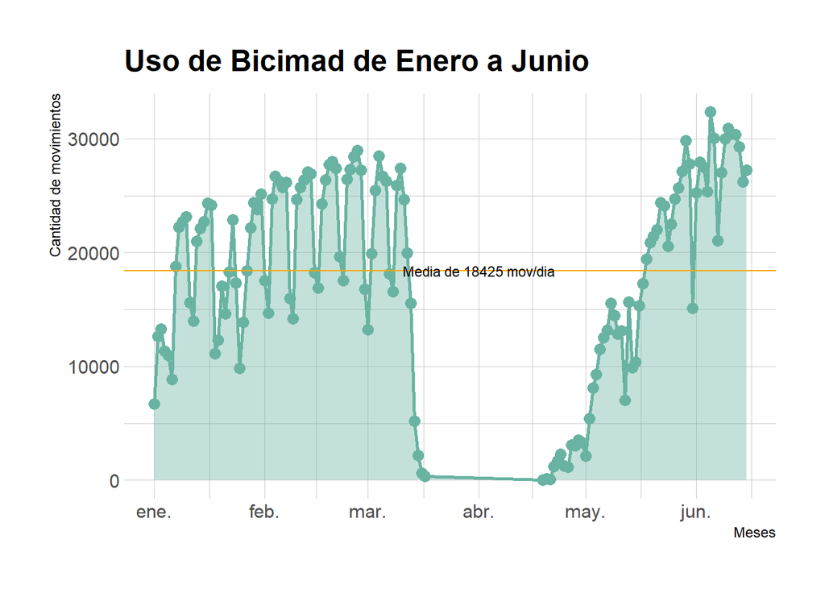

```r
media = mean(final$totalmov)

ggplot(final, aes(x=fecha, y=totalmov)) + geom_area(size=1,fill="#69b3a2", alpha=0.4) + geom_line(color="#69b3a2", size=1) + labs(title ="Uso de Bicimad de Enero a Junio", x = "Meses", y = "Cantidad de movimientos")+ geom_point(size=3, color="#69b3a2")+ theme_ipsum()+
  geom_hline(yintercept= media, color="orange", size=.5)+
  annotate(geom="text", x=as.Date("2020-04-01"), y=media,
             label="Media de 18425 mov/dia", size=3)
```

A continuación se muestra una relación entre la temperatura y el uso de Bicimad, se comprueba como a medida que la temperatura aumenta, durante la primera mitad del año, tambien aumenta el uso de bicicleta

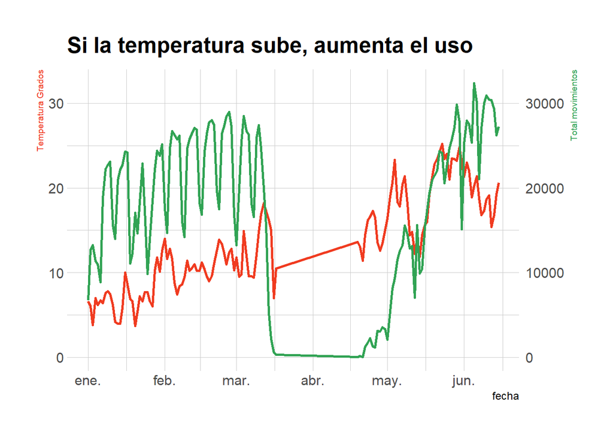

```r
# Valor usado para transformar los datos
coeff <- 1000

# Definimos los colores
temperatureColor <- "#f03b20"
movColor <- "#31a354"

ggplot(final, aes(x=fecha)) +

  geom_line( aes(y=tmed), size=1, color=temperatureColor) +
  geom_line( aes(y=totalmov / coeff), size=1, color=movColor) +

  scale_y_continuous(

    # Personalizamos el primer eje
    name = "Temperatura Grados",

    # Personalizamos el segundo eje y lo ajustamos
    sec.axis = sec_axis(~.*coeff, name="Total movimientos")
  ) +

  theme_ipsum() +

  theme(
    axis.title.y = element_text(color = temperatureColor, size=7),
    axis.title.y.right = element_text(color = movColor, size=7)
  ) +

  ggtitle("Si la temperatura sube, aumenta el uso")
```

En este otro apartado se aprecia como los días que más llueve, el uso de Bicimad desciende en la ciudad. En este caso hay pocos días de lluvia, pero se ve claramente el descenso.

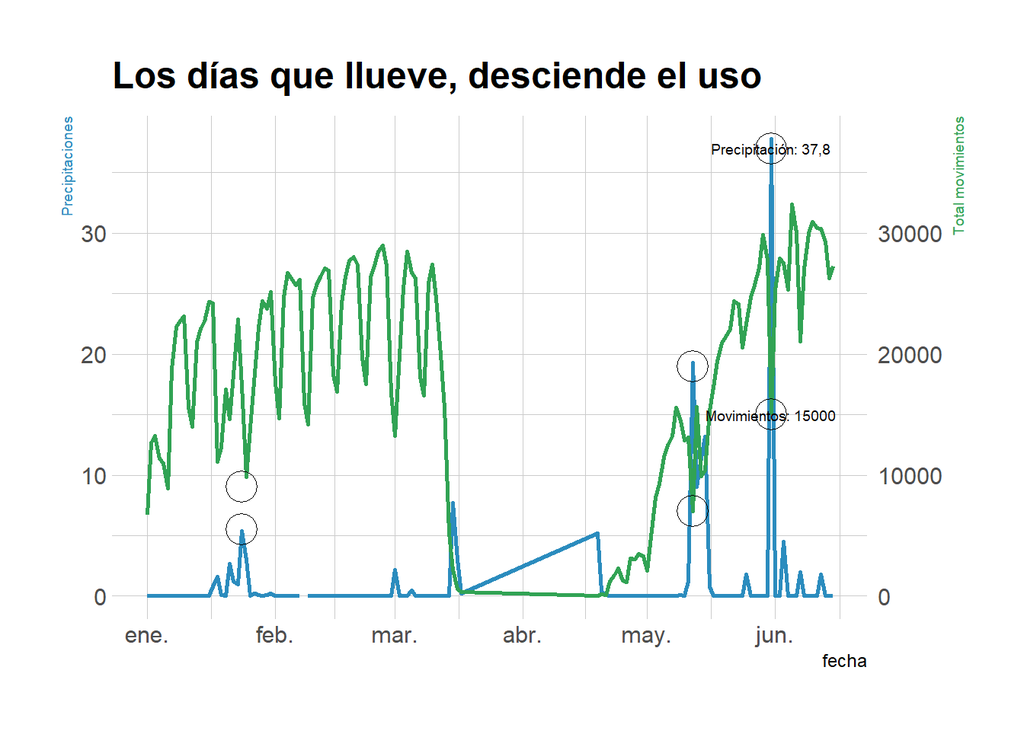

```r
# Valor usado para transformar los datos
coeff <- 1000

# Definimos los colores
preciColor <- "#2b8cbe"
movColor <- "#31a354"

ggplot(final, aes(x=fecha)) +

  geom_line( aes(y=prec), size=1, color=preciColor) +
  geom_line( aes(y=totalmov / coeff), size=1, color=movColor) +

  scale_y_continuous(

    # Personalizamos el primer eje
    name = "Precipitaciones",

    # Personalizamos el segundo eje y lo ajustamos
    sec.axis = sec_axis(~.*coeff, name="Total movimientos")
  ) +

  theme_ipsum() +

  theme(
    axis.title.y = element_text(color = preciColor, size=7),
    axis.title.y.right = element_text(color = movColor, size=7)
  ) +

  ggtitle("Los días que llueve, desciende el uso")+
  annotate(geom="text", x=as.Date("2020-05-31"), y=37,
  label="Precipitación: 37,8", size=2.5) +
  annotate(geom="point", x=as.Date("2020-05-31"), y=37, size=7, shape=21, fill="transparent") +
  annotate(geom="text", x=as.Date("2020-05-31"), y=15,
  label="Movimientos: 15000", size=2.5) +
  annotate(geom="point", x=as.Date("2020-05-31"), y=15, size=7, shape=21, fill="transparent")+
  annotate(geom="point", x=as.Date("2020-05-12"), y=19, size=7, shape=21, fill="transparent")+
  annotate(geom="point", x=as.Date("2020-05-12"), y=7, size=7, shape=21, fill="transparent")+
  annotate(geom="point", x=as.Date("2020-01-24"), y=5.5, size=7, shape=21, fill="transparent")+
  annotate(geom="point", x=as.Date("2020-01-24"), y=9, size=7, shape=21, fill="transparent")
```

Se podrian analizar con más detalle los datos, o incluso utilizar otras variables de las que hemos obtenido. Pero en este caso, no quería entrar en mayor detalle, si no, mostrar el proceso para conseguir el objetivo de obtener los datos, tratarlos y usarlos para un fin concreto.